# ESM 206 Lab 5

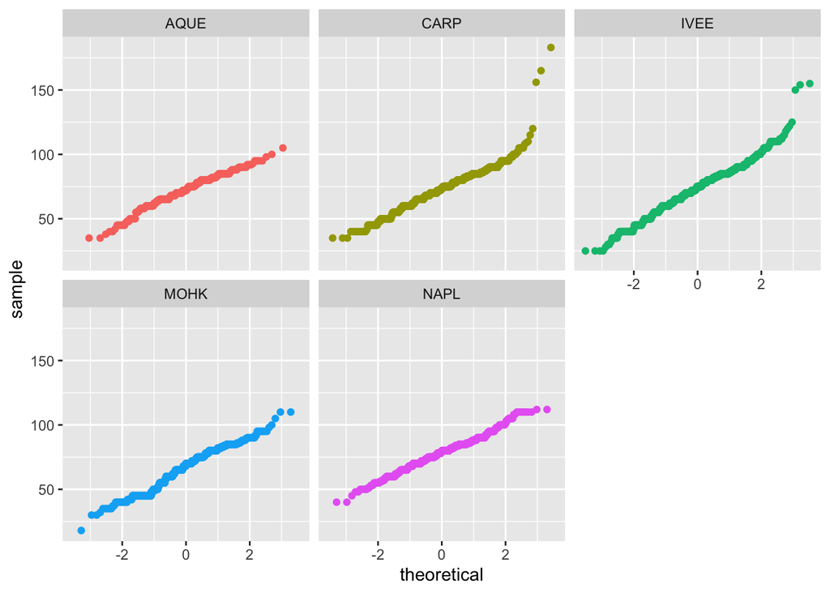

```r
# facet_wrap(~) - remember!
# 'scales = "free"' means scales differ for each different facet, can be misleading if you're comparing across groups

# Are these distributions normal? Let's check with a quantile-quantile plot!

ggplot(lobster_tidy, aes(sample = size_mm)) +
  geom_qq(aes(color = site),
          show.legend = FALSE) +
  facet_wrap(~site)
```

```r
# Need to choose a sample to geom_qq to compare
# geom_qq() has a default normal distribution built into it - the sample is what we are testing
```

Use ‘lubridate’ package to parse dates and times

- We tend to specify package (“lubridate::”) because these names are generic and tend to exist in other packages
- Check class of data with ‘class(lobster_tidy$date)’ in console
- I’m going to add a new column with ‘mutate()’ that contains my date as an actual date
- This will also change the class to date

```r
lobster_date <- lobster_tidy %>%
  mutate(date_new = lubridate::mdy(date))
```

Parse ‘date’ column to get the different pieces (month, year) separated

```r
lobster_parse_date <- lobster_date %>%
  mutate(
    obs_month = lubridate::month(date_new,
                                 label = TRUE),
    obs_year = lubridate::year(date_new)
    )

# label = TRUE gives us month name instead of number!
# This also makes it already factored with levels of all the months
# Can check with class() & see it's an ordered factor, then can check with levels() to see all the levels (months) of the factor
```

Count lobsters by different groupings…

- Can use **count()**
- says group_by, then summarise, then find the length, then ungroups.
- is awesome if we have categorical data

Let’s say I want to count the number of lobsters by year and month

```r
lobster_ym <- lobster_parse_date %>%
  count(obs_year, obs_month)

# Titles up total observations that exist

lobster_ym
```

```
## # A tibble: 8 x 3
##   obs_year obs_month     n
##      <dbl> <ord>     <int>
## 1     2012 Aug         231
## 2     2013 Aug         243
## 3     2014 Aug         404
## 4     2014 Sep         106
## 5     2015 Aug        1100
## 6     2016 Aug         809
## 7     2017 Aug        1668
## 8     2018 Aug        1805
```

```r
lobster_ysite <- lobster_parse_date %>%
  count(obs_year, site)

lobster_ysite
```

```
## # A tibble: 35 x 3
##    obs_year site      n
##       <dbl> <chr> <int>
##  1     2012 AQUE     38
##  2     2012 CARP     78
##  3     2012 IVEE     26
##  4     2012 MOHK     83
##  5     2012 NAPL      6
##  6     2013 AQUE     32
##  7     2013 CARP     93
##  8     2013 IVEE     40
##  9     2013 MOHK     15
## 10     2013 NAPL     63
## # … with 25 more rows
```

```r
lobster_site <- lobster_parse_date %>%
  count(site)

lobster_site
```

```
## # A tibble: 5 x 2
##   site      n
##   <chr> <int>
## 1 AQUE    422
## 2 CARP   1619
## 3 IVEE   2304
## 4 MOHK    982
## 5 NAPL   1039
```

Key has more examples for functions to use to make tables for more than just count - group_by + summarize + n()

```r
lobster_summary <- lobster_parse_date %>%
  group_by(site) %>%
  summarize(
    mean_size = mean(size_mm,
                     na.rm = TRUE),
    sd_size = sd(size_mm,
                 na.rm = TRUE),
    sample_n = n()
  )

# Not responsible to just give the mean of data without also giving the standard deviation and the sample size

# There is also tally(), but count is a combination between group_by() & tally()
```

Confidence intervals and t-tests

t distribution is what you’ll use if you don’t know the population variance, accounts for uncertainty that comes with not knowing that

**One-sample t-test**

Use the “t.test()” function to find confidence intervals and perform t-tests

```r
ivee_lobsters <- lobster_tidy %>%
  filter(site == "IVEE") %>%
  pull(size_mm)

# this creates a vector with the lobster size values
# Now we can use the t.test() on a vector - will calculate one-sample t-test and confidence intervals
# Deduces what you want to do based on how many vectors you give it

t.test(ivee_lobsters)
```

```
##
##  One Sample t-test
##
## data:  ivee_lobsters
## t = 245.23, df = 2302, p-value < 2.2e-16
## alternative hypothesis: true mean is not equal to 0
## 95 percent confidence interval:
##  72.99130 74.16806
## sample estimates:
## mean of x
##  73.57968
```

**Confidence Interval**

If we took a bunch of samples and got the means for all of them - I would expect the sample mean to fall within this range (72.99-74.16) 95% of the time - This does not mean “there is a 95% chance the mean is in this range” - It’s in 95% of other samples I take - based on sampling distribution, not on the data

**Two-sample t-test**

Is there a significant difference between lobsters measured at Naples Reef and those measures at Mohawk reef?

```r
napl_sample <- lobster_tidy %>%
  filter(site == "NAPL") %>%
  pull(size_mm)

mohk_sample <- lobster_tidy %>%
  filter(site == "MOHK") %>%
  pull(size_mm)

mohk_napl_ttest <- t.test(napl_sample,
                          mohk_sample)

mohk_napl_ttest
```

```
##
##  Welch Two Sample t-test
##
## data:  napl_sample and mohk_sample
## t = 19.849, df = 1850.8, p-value < 2.2e-16
## alternative hypothesis: true difference in means is not equal to 0
## 95 percent confidence interval:
##  10.19806 12.43436
## sample estimates:
## mean of x mean of y
##  78.18454  66.86833
```

**p-value** here tells us there is only a 2.2*10^-16 probability that we could’ve taken two samples from a population with the same mean and received the means that are this different, so, the more likely explanation is that they were drawn from populations with different means

Answers “did it happen from random chance?” PROBABLY NOT

Actual sentence we would put in our actual report:

*Mean lobster size differed significantly between Mohawk and Naples Reefs (t(1850.7720862) = 19.8487322).*

- Note: we may typically write “(t(1850.8) = 19.849)”, but doing this allows room for error in writing or copying and pasting - so we call these value with `r`
- Can see what terms to use in ?t.test > values (i.e. how we know degrees of freedom can be referenced with “parameter”)